# NPS - Exploratory analysis in R

Nitin Ahuja

2017-08-28

# NPS analysis

## What is net promorter score (NPS)?

Net Promoter Score or NPS is a customer loyalty metric and was developed by Fred Reichheld and it asks respondents to answer a single question. > How likely are you to recommend this product? The respondents are asked to score between 0 and 10. 10 being “most likely” to recommend and 0 being “least likely”.

An additional optional question is asked about why they picked this score and the response to that is usually a text comment. We will make an attempt to summarize the text as well.

I have NPS scores from customers of a platform that allows them to sell widgets. These scores were collected over a two year period Jun 2015 - Jun 2017, and this is an attempt to perform some exploratory data analysis and see if some more value can be extracted from this data.

Note that some of this data has been sanitized of proprietary information but the scores have been left untouched.

First, let’s load up some packages.

```r
library(NPS)

library(ggplot2)
library(lubridate)
library(dplyr)
library(tidyr)
library(RColorBrewer)
library(ggridges)
library(reshape2)

library(tidytext)
library(wordcloud)
library(tm)
library(stringr)
library(SnowballC)

theme_set(theme_minimal())
```

## Analyze the data.

Next load up the data and take a look.

```r
nps <- read.csv('~/data/nps.csv', header = TRUE, quote = '"'
                , na.strings=c("", "NA", "#N/A")
                , colClasses = c("Feedback.Received"= "Date"
                               , "Comment"="character"
                               , "Survey.Sent"="Date"
                               , "TPY"="integer"
                               ))
```

Let’s take a look at the data. Here is some summarized information for this data

Summarized details

```
   Vertical              TPY          Non.Profit             Sent               Received              Score        promoter.tags      detractor.tags
 Length:8423        Min.   :   -40   Length:8423        Min.   :2015-06-23   Min.   :2015-06-23   Min.   : 0.000   Length:8423        Length:8423
 Class :character   1st Qu.:  1799   Class :character   1st Qu.:2016-01-17   1st Qu.:2015-12-31   1st Qu.: 7.000   Class :character   Class :character
 Mode  :character   Median :  4816   Mode  :character   Median :2016-07-18   Median :2016-06-22   Median : 9.000   Mode  :character   Mode  :character
                    Mean   : 10101                      Mean   :2016-07-04   Mean   :2016-06-17   Mean   : 7.824
                    3rd Qu.: 10535                      3rd Qu.:2016-12-16   3rd Qu.:2016-11-27   3rd Qu.:10.000
                    Max.   :600000                      Max.   :2017-06-05   Max.   :2017-06-05   Max.   :10.000
                    NA's   :41                          NA's   :1632         NA's   :6824         NA's   :6824
```

## NPS

Let’s start by getting the NPS for this data. NPS scores can vary from -100 (all detractors) to 100 (all promoters). Note that the while NPS is expressed as a number between -100 and 100, the CRAN NPS package returns results from [-1,1]. All plots use the returned results and ideally should be multiplied by 100 and rounded. Before we can calculate that number we will need to ensure that our data actually has scores.

Let’s drop all rows that don’t have Scores.

```r
nps <- nps %>%
    drop_na(Score)
```

That leaves us with 1599 rows.

Let’s enrich this data just a little bit. We’ll add a column for the day of the week, month, year of received date and the days to respond. We have also added categories based on the Score. Respondents who score from 0 through 6 are considered *detractors* of the service, 7 - 8 are *passives* and 9 and 10s are considered *promorters*.

```r
nps$year <- as.factor(year(nps$Received))
nps$month <- cut(nps$Received, breaks = "month")
nps$days <- nps$Received - nps$Sent
nps$weekday <- weekdays(nps$Received)
nps$weekday <- factor(nps$weekday, levels = c("Sunday", "Monday", "Tuesday", "Wednesday", "Thursday", "Friday", "Saturday"))
nps$cat <- cut(nps$Score, breaks = c(-1, 6, 8, 10), labels = c("Detractor", "Passive", "Promoter"))
```

### Overall NPS Score

What’s the overall NPS score?

```r
nps(nps$Score,  breaks = list(0:6, 7:8, 9:10))
```

```
[1] 0.2826767
```

### Yearly changes

Has there been any change in the score over time?

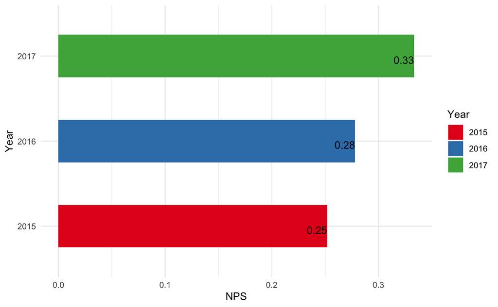

```r
yearly <- aggregate(nps$Score, list(nps$year), FUN = nps, nps$Score)

ggplot(yearly) +
  geom_col(aes(x=as.factor(Group.1), y=x, fill=as.factor(Group.1)), width=0.5) +
  xlab("Year") +
  ylab("NPS") +
  geom_text(aes(x=as.factor(Group.1), y=x, label=round(x,2)),  vjust = 1, hjust = 1)  +
  coord_flip()  +
  scale_fill_brewer("Year", palette = "Set1")
```

Looks like there has been a consistent improvement over the years.

### Monthly changes

Looking at the score monthly over time we can see that there is an upward trend but the growth is not consistent.

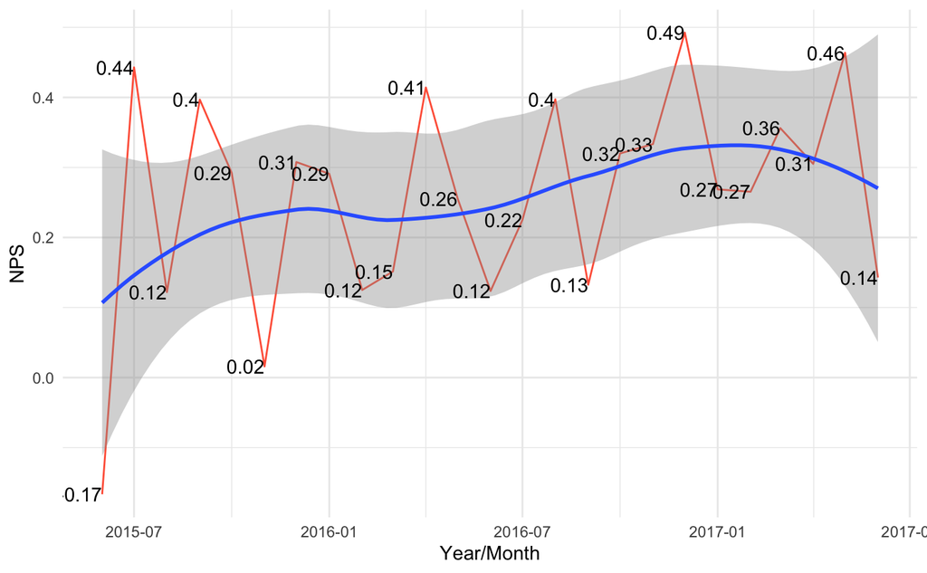

```r
np <- aggregate(nps$Score, list(nps$month), FUN = nps, nps$Score)

ggplot(np, aes(x=as.Date( Group.1), y=x)) +
  geom_line(color = "tomato") +
  geom_smooth(method = "loess") +
  xlab("Year/Month") +
  ylab("NPS") +
  geom_text(aes( y=x, label=round(x,2)), position = position_dodge(width = 1), vjust = 0.5, hjust=1)  +
  theme_minimal()
```

## Exploring some other dimensions

Are there other dimensions that affect NPS?

### Day of the week

Does the day of the week affect the score?

Looks like responses provided on Wednesday have a higher score. Might be something worth exploring to see if this is just random chance or if this is something real.

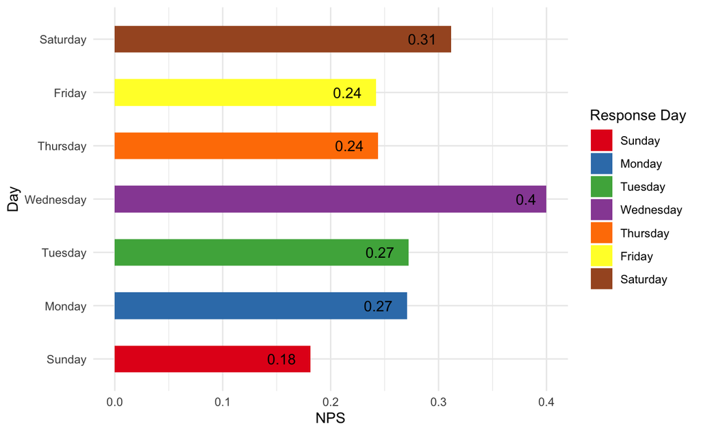

```r
daily <- aggregate(nps$Score, list(nps$weekday), FUN = nps, nps$Score)

daily$Group.1 <- factor(daily$Group.1, levels = c("Sunday", "Monday","Tuesday", "Wednesday", "Thursday", "Friday", "Saturday"))

ggplot(daily) +
  geom_col(aes(x=as.factor(Group.1), y=x, fill=as.factor(Group.1)), width=0.5) +
  xlab("Day") +
  ylab("NPS") +
  geom_text(aes(x=as.factor(Group.1), y=x, label=round(x,2)),  vjust = 0.5, hjust = 1.5)  +
  coord_flip()  +
  scale_fill_brewer("Response Day", palette = "Set1")
```

One more view of the scores by day; do respondents leave higher score on some days?

### Day of Week vs Scores

This plot shows the kernel density of the scores (0-10) received by day. It seems that respondents who leave scores on Wednesday seem to provide more 10s compared to Sunday. In fact, there seems to be a bi-modal distribution on Sunday with 5s and 10s.

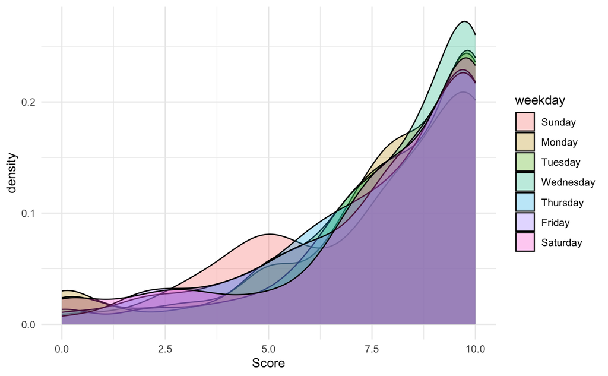

```r
ggplot(nps) +
  geom_density(aes( x = Score,  group = weekday, fill = weekday), alpha = 0.3)
```

Here is a ridges plot for the score density by day. It’s harder to compare the relative heights of the score density compared to the density plot above. The bi-modal distribution of scores on Sunday is, however, quite clear here.

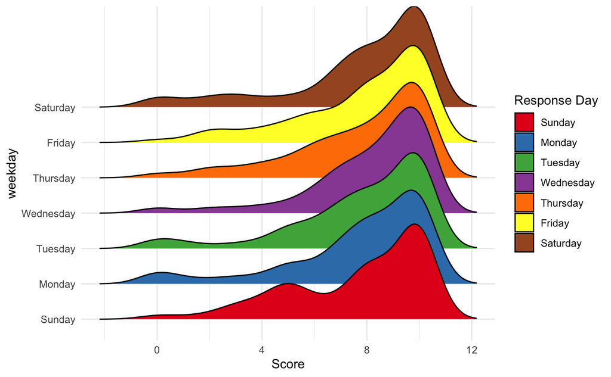

```r
ggplot(nps) +
  geom_density_ridges(aes( x = Score, y = weekday, fill = weekday), scale = 3) +
  scale_fill_brewer("Response Day", palette = "Set1")
```

### Time to respond.

How long are respondents taking to respond?

It seems like most responses are received on the same day as the survey was sent. There is a peak on the 5th day as well. Given the fact that responses on Wednesday seems to generate higher scores, if requests are sent on Wednesday, it may skew towards more positive scores.

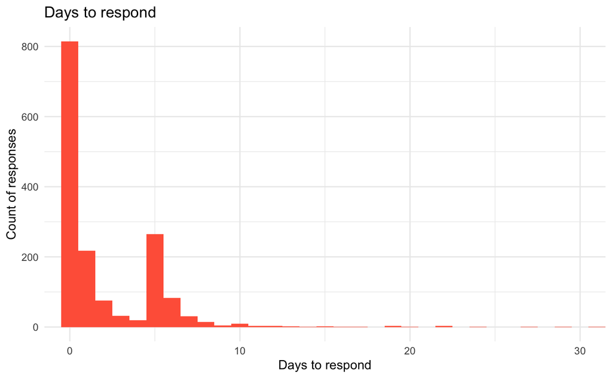

```r
ggplot(nps) +
  geom_histogram(aes(as.numeric( days)), binwidth = 1, fill = "tomato") + labs(title = "Days to respond", x = "Days to respond", y = "Count of responses")  +
  coord_cartesian(xlim = c(0,30))
```

### Scores over the years

How have the scores changed over time?

Has the median score shifted over the years?

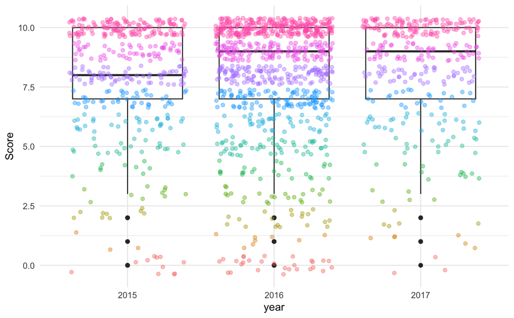

```r
ggplot(subset(nps, !is.na(year)), aes(y=Score, x=year)) +
  geom_boxplot() +
  geom_point( position = "jitter", alpha = 0.4, aes(color=as.factor(Score))) +
  guides(color=FALSE)
```

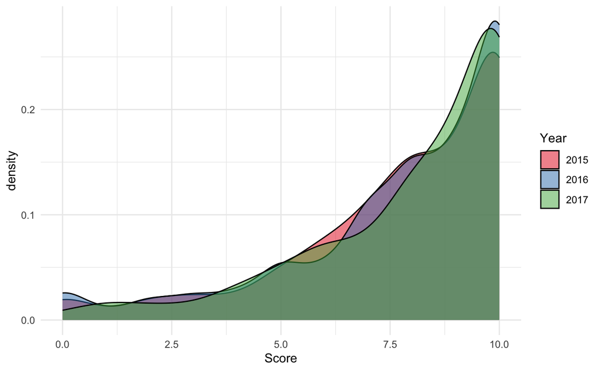

```r
ggplot(nps) + geom_density(aes(x=Score, fill = year, binwidth =1 ), alpha = 0.5) + coord_cartesian(xlim = c(0,10)) +
   scale_fill_brewer("Year", palette = "Set1")
```

To see a percentage distribution, we can plot the cumulative frequency distribution of the Score categories grouped by year. The plot shows what percentage of Scores fall into which category groups.

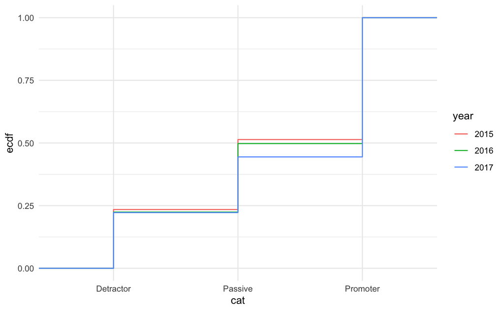

```r
ggplot(nps) +
  stat_ecdf(aes(x=cat, group = year, colour = year))
```

The table below shows the exact percentage of category groups by year. One can see that while the percentage of *detractors* has remained somewhat static over the years, some of the *passive* group has shifted to being *promorters*.

```r
nps %>%
  group_by(year, cat) %>%
  summarise(cat_count = length(cat)) %>% mutate(pct = round((cat_count/sum(cat_count)*100),2))
```

| year | cat | cat_count | pct |
| --- | --- | --- | --- |
| 2015 | Detractor | 94 | 23.44 |
| 2015 | Passive | 112 | 27.93 |
| 2015 | Promoter | 195 | 48.63 |
| 2016 | Detractor | 196 | 22.43 |
| 2016 | Passive | 239 | 27.35 |
| 2016 | Promoter | 439 | 50.23 |
| 2017 | Detractor | 72 | 22.22 |
| 2017 | Passive | 72 | 22.22 |
| 2017 | Promoter | 180 | 55.56 |

### TPY

Recall that TPY is a measure of the widgets sold on the platform. Does the TPY affect score? We are going to create some groups based on the TPY number. It seems clear that the customers at 20,000 and below TPY levels are happier than the larger sized customers.

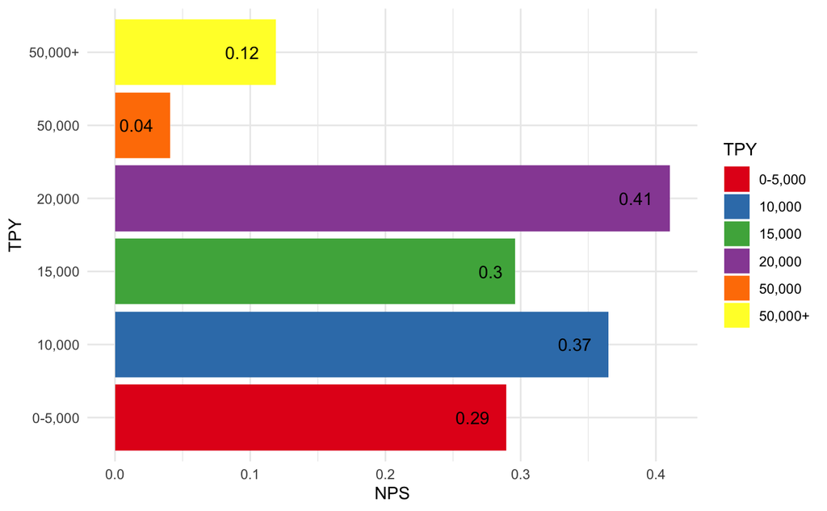

```r
# Add TPY levels
nps$tp_level <- cut(nps$TPY, breaks=c(-1,5000, 10000, 15000, 20000, 50000, +Inf), labels = c("0-5,000", "10,000", "15,000", "20,000", "50,000", "50,000+"))


tix <- aggregate(nps$Score, list(nps$tp_level), FUN = nps, nps$Score)

ggplot(tix) +
  geom_col(aes(x=as.factor(Group.1), y=x, fill=as.factor(Group.1))) +
  xlab("TPY") +
  ylab("NPS") +
  geom_text(aes(x=as.factor(Group.1), y=x, label=round(x,2)), position = position_dodge(width = 1), hjust=1.5) +
  scale_fill_brewer("TPY", palette = "Set1") +
  coord_flip()
```

### For profit vs non-profit customers

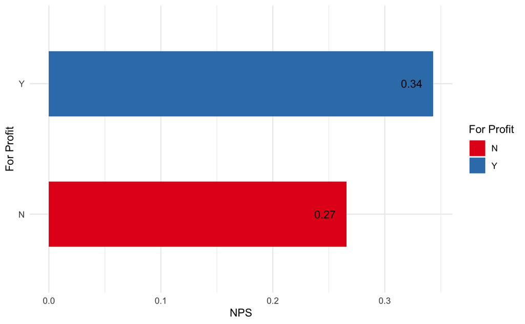

```r
profit <- nps %>%
  filter(!is.na(Non.Profit)) %>%
  group_by(Non.Profit) %>%
  summarise(nps = nps(Score))

ggplot(profit) +
  geom_col(aes(x=Non.Profit, y=nps, fill=Non.Profit), width=0.5) +
  xlab("For Profit") +
  ylab("NPS") +
  geom_text(aes(x=Non.Profit, y=nps, label=round(nps,2)), position = position_dodge(width = 1), hjust=1.5) +
  scale_fill_brewer("For Profit", palette = "Set1") +
  coord_flip()
```

### Verticals

The data has a column that shows the vertical of the respondent. This is an indicator of the category of widget being sold by the platform.

The PrA vertical has the largest number of respondents.

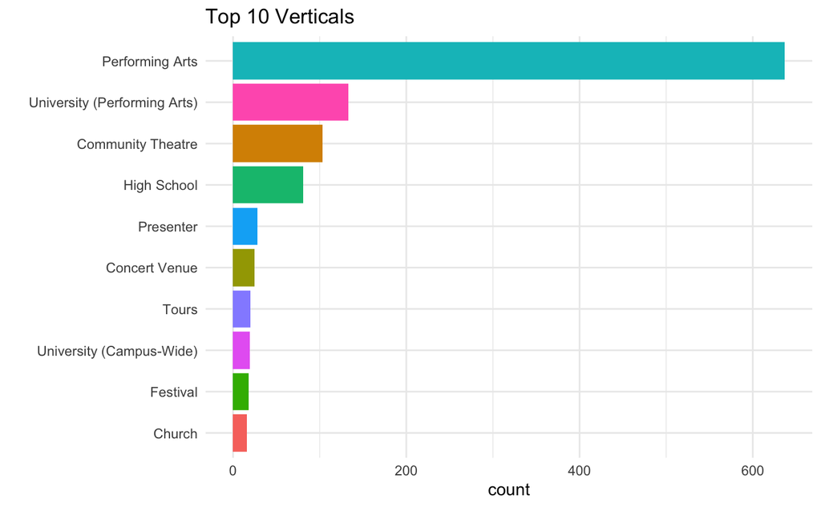

```r
vertical <- nps %>%
  filter(!is.na(Vertical)) %>%
  group_by(Vertical) %>%
  tally() %>%
  top_n(10)
ggplot(vertical, aes(x=reorder(Vertical, n), y = n)) +
  geom_col(aes(fill = Vertical))  +
  guides(fill=FALSE) +
  ggtitle("Top 10 Verticals") +
  xlab("") +ylab("count") +
  coord_flip()
```

### Score by Vertical

What’s the NPS score by Vertical? There seems to be a large variation of NPS by Vertical. Not sure if some connection should be derived from this. This may be something to explore further.

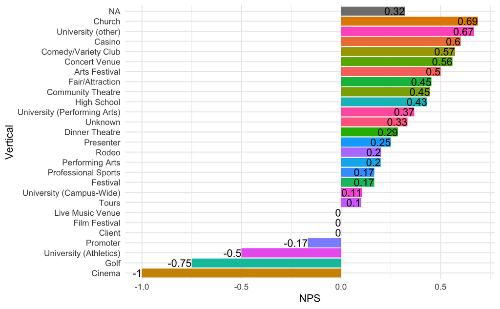

```r
vert_score <- nps  %>%
  group_by(Vertical) %>%
  summarise(nps = nps(Score))

ggplot(vert_score) +
  geom_col(aes(x=reorder(Vertical, nps), y=nps, fill=Vertical)) +
  guides(fill=FALSE) +
  coord_flip() +
  scale_fill_discrete(name = "Vertical") +
  ylab("NPS") + xlab("Vertical") +
  geom_text(aes(x=Vertical, y=nps, label=round(nps,2)), position = position_dodge(width = 1),vjust = 0.5, hjust=1)
```

As evident from this that there are several dimensions to guide us about the respondents and what they like about the platform. The next steps here would be to try and perform classification and machine learning techniques to examine this data further.

Before we get into ML, let’s perform some more exploration on the text included in the data.

# Text Analysis

This part will try to analyze the sentiment of the comments to perhaps try and understand what the detractors don’t like and what the promoters like. To do this we will try and perform the following tasks.

## Introduction

### Tokenization

We will keep the categories in place to see how the sentiment correlates to the scores. Let’s see how many comments we have from each category.

```r
comments <- nps %>%
  filter(!is.na(Comment)) %>%
  select(cat, Comment) %>%
  group_by(row_number(), cat)

comments <- comments %>% ungroup()
```

Next we will use *unnest_tokens* from the tidytext package to tokenize the words while retaining the corresponding categories. We end up with about 24,000 words.

```r
nps_words <- comments %>% unnest_tokens(word, Comment)
nps_words
```

| cat | row_number() | word |
| --- | --- | --- |
| Promoter | 1 | customer |
| Promoter | 1 | service |
| Promoter | 2 | intuitive |
| Promoter | 2 | program |
| Promoter | 2 | and |
| Promoter | 2 | accessible |
| Promoter | 2 | support |
| Promoter | 3 | easy |
| Promoter | 3 | to |
| Promoter | 3 | use |

[output cut: 990 more lines]

Our next step is to remove some common words that are not useful for analysis. These include pronouns, articles and other common words. The tidytext package already includes a wide range of these in the *stop_words* dataset.

```r
nps_words <-  nps_words %>% anti_join(stop_words, by = c('word'))
nps_words %>% count(word, sort = TRUE)
```

| word | n |
| --- | --- |
| platform | 353 |
| service | 280 |
| customer | 229 |
| system | 191 |
| support | 187 |
| easy | 155 |
| ease | 142 |
| ticket | 91 |
| friendly | 89 |
| user | 84 |

[output cut: 990 more lines]

## Sentiment Analysis

The plot below shows the sentiments grouped by the category using the *Afinn* dictionary. The Afinn dictionary assigns a score from -5 to 5 with -5 being negative words and 5 being positive. It’s clear that the detractor comments are less positive than the promoters.

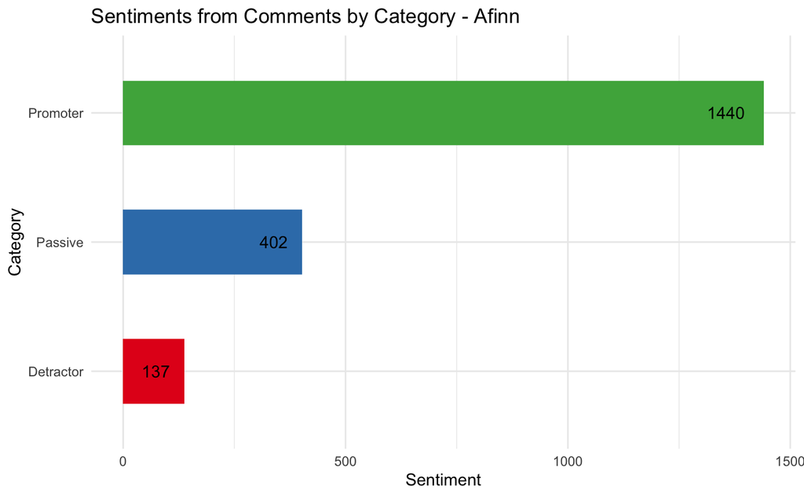

Let’s try another lexicon. This one is called *Bing* and was produced by Bing Liu et al. This classifies words with a label signifying positive or negative. Here is a sample of words from this lexicon.

| word | sentiment |
| --- | --- |
| 2-faces | negative |
| abnormal | negative |
| abolish | negative |
| abominable | negative |
| abominably | negative |
| abominate | negative |
| abomination | negative |
| abort | negative |
| aborted | negative |
| aborts | negative |

[output cut: 990 more lines]

Next, let’s look at the sentiments for each category using the *Bing* dictionary.

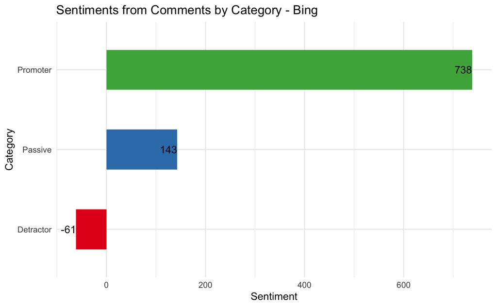

```r
nps_words %>%
  inner_join(get_sentiments("bing"), by = c('word')) %>%
  count(cat, sentiment) %>%
  spread(sentiment, n, fill = 0) %>%
  mutate(sentiment = positive - negative) %>%
ggplot(aes(x=cat, y = sentiment, fill = cat)) +
  geom_col(width = 0.5) +
  coord_flip() +
  geom_text(aes(x=cat, y=sentiment, label=sentiment), position = position_dodge(width = 1), hjust=1) +
  scale_fill_brewer(palette = "Set1") +
  guides(fill=FALSE) +
  labs(title = "Sentiments from Comments by Category - Bing", x = "Category", y = "Sentiment")
```

While both lexicons show the same relative trends and proportions, the absolute numbers vary significantly. It might be worth taking a quick look at the words that are contributing to each sentiment.

### Ranking and tf-idf

The statsitic *tf-idf* measures how important a term is to a document in a collection of documents. So in our context we are trying to see if a term/word has special meaning in one respondent’s comments in relation to *all* other comments.

## Conclusion

Here are a few clear takeaways from this analysis

- *Passive* respondents from prior years have become *Promorters*.
- Respondents seem to provide higher Scores on *Wednesday*.
- *Customer Service* has a huge positve impact on the scores.
- Response rates are quite low - 19 percent
- Product is generally *user friendly*.
- Low and mid segment users are happier than higher sales respondents.